# Code to Generate Charts and Network Visualizations for:

## The Imaginative Networks of Early Modern Print

**n.b.**: This Jupyter notebook contains nowhere near the full amount of code used on this project. All code for named-entity recognition, XML parsing, generating the initial network, and creating the website can be found at [the front_matter Github repo](https://github.com/jrladd/front_matter), though the code there has not yet been cleaned up for public inspection.

This notebook instead contains the code for generating the graphs and the non-D3 network visualizations that appear in the online version of my final disseration chapter.

```python
# Begin by importing necessarly libraries
import networkx as nx
from networkx.readwrite import json_graph
from networkx.algorithms import bipartite, community
import json
import matplotlib
import matplotlib.pyplot as plt
import pandas as pd
import sqlite3

plt.style.use('ggplot') # Automatically give all charts nice styling
```

```python
# Read in the full initial graph from my named-entity recognition process
with open('all_eebo.json', 'r') as jsonfile:
    jsonstring = jsonfile.read()
    data = json.loads(jsonstring)
```

```python
# Load this graph into a NetworkX object for easy analysis
B = json_graph.node_link_graph(data)
print(nx.info(B))
```

```
Name:
Type: Graph
Number of nodes: 41619
Number of edges: 51123
Average degree:   2.4567
```

## Create Projected Graphs

In order to track the relative centralities of people and texts, it was necessary to create and visualize two "projected" graphs that show people connected in terms of the texts that cite them and texts connected in terms of the people they cite. (See the chapter for a fuller definition of projection.)

I then exported these graphs as Gephi-ready import files, where I created the "Network of People" and "Network of Texts" visualizations that appear on the main site.

```python
# Isolate the two sets of nodes in the main bipartite graph
people_nodes = {n for n, d in B.nodes(data=True) if d['bipartite']==1}
text_nodes = set(B) - people_nodes
```

```python
# Create a NetworkX graph of people
P = bipartite.weighted_projected_graph(B, people_nodes)
print(nx.info(P))
```

```
Name:
Type: Graph
Number of nodes: 29368
Number of edges: 311822
Average degree:  21.2355
```

```python
# Create a NetworkX graph of texts
T = bipartite.weighted_projected_graph(B, text_nodes)
print(nx.info(T))
```

```
Name:
Type: Graph
Number of nodes: 12251
Number of edges: 4114227
Average degree: 671.6557
```

```python
# This function for writing NetworkX objects to JSON was useful when I was initially
# going to create D3 visualizations. It's preserved here but unused in the final project.
def write_json(B, filename):
    """
    Given NetworkX graph object and filename, create JSON representation for D3.
    """
    print("Writing JSON file...")
    new_data = json_graph.node_link_data(B)
    with open(filename, 'w') as output:
        json.dump(new_data, output, sort_keys=True, indent=4, separators=(',',':'))
```

```python
# These projected networks have too many edges to be useful.
# It's impossible to see patterns when looking at all possible connections.
# For simplicity, I removed connections in which two people shared only one text.
fewer_edges = {(s,t) for s,t,d in P.edges(data=True) if d['weight']>1}
print(len(fewer_edges))
PS = P.edge_subgraph(fewer_edges)
print(nx.info(PS))
```

```
9148
Name:
Type: Graph
Number of nodes: 3078
Number of edges: 9148
Average degree:   5.9441
```

```python
# Similarly, with texts, I removed connections where two texts shared only two or fewer people.
text_fewer_edges = {(s,t) for s,t,d in T.edges(data=True) if d['weight']>2}
print(len(text_fewer_edges))
TS = T.edge_subgraph(text_fewer_edges)
print(nx.info(TS))


# Additional data cleanup (using TCP metadata) was needed
conn = sqlite3.connect('../data/eebo_tcp_metadata.sqlite')
c = conn.cursor()

for text_id,data in TS.nodes(data=True):
    c.execute('SELECT title,author,date FROM metadata WHERE key=?', (text_id,))
    fetched = c.fetchone()
    if fetched == None:
        new_title = "Not Found"
        new_author = "Not Found"
        new_date = "Not Found"
    else:
        new_title = fetched[0]
        new_author = fetched[1]
        new_date = fetched[2]

    TS.node[text_id]['title'] = new_title
    TS.node[text_id]['author'] = new_author
    TS.node[text_id]['date'] = new_date

#Export the file in Gephi format
#nx.write_gexf(TS, "texts.gexf")
conn.close()
```

```
6008
Name:
Type: Graph
Number of nodes: 1130
Number of edges: 6008
Average degree:  10.6336
```

```python
# Data cleanup needed for People graph export as well
for n in PS.nodes(data=True):
    del PS.node[n[0]]['author']
    del PS.node[n[0]]['title']
    del PS.node[n[0]]['date']
```

```python
# Write People network to file
nx.write_gexf(PS, "people.gexf")
```

```python
#Who are the top nodes by degree in the people graph? Sort and output a simple list

people_by_degree = sorted(P.nodes(data=True), key=lambda p:p[1]['degree'], reverse=True)
print(people_by_degree[:10])
```

```
[('1014540', {'bipartite': 1, 'deg_rank': 1, 'degree': 8198, 'name_variants': 'Jesus Christ'}), ('1025452', {'bipartite': 1, 'deg_rank': 2, 'degree': 834, 'name_variants': "['St. Paul', 'St. Pauli', 'St. Paull', 'St. Paul,1', 'St. Paulus', 'St. Paule,1', 'St. Pauls', 'St. Paulin', 'St. Paule', 'St. …
```

## Analyzing Networks Over Time

After creating projected graphs for the entire span of the early modern period, I needed a way of understanding the network data that did not flatten the dimension of time. In the following code, I created sliced networks (subgraphs) for every year of the period, so that I might trace centrality measures and other metrics over time.

```python
def filter_by_year(year):
    """
    A function for creating subgraphs for each year
    """
    nodes = []
    for n in B.nodes(data=True):
        try:
            if n[1]['date'] == year:
                nodes.append(n[0])
                nodes.extend(B.neighbors(n[0]))
        except KeyError:
            pass
    SB = B.subgraph(nodes)
    return SB
```

```python
# As a test, create a subgraph for 1575
SB = filter_by_year(1575)
print(nx.info(SB))
```

```
Name:
Type: Graph
Number of nodes: 110
Number of edges: 96
Average degree:   1.7455
```

```python
# A few years in the late 15th century had no connections at all.
# I needed to figure out what those years were so I could eliminate them
dates = []
for n in text_nodes:
    try:
        date = B.node[n]['date']
        if date not in dates:
            dates.append(date)
    except KeyError:
        pass


dates.remove(None)
print(sorted(dates))
```

```
[1474, 1482, 1490, 1525, 1528, 1529, 1531, 1532, 1534, 1535, 1536, 1537, 1538, 1539, 1540, 1542, 1543, 1544, 1545, 1546, 1547, 1548, 1549, 1550, 1551, 1552, 1553, 1554, 1555, 1556, 1557, 1558, 1559, 1560, 1561, 1562, 1563, 1564, 1565, 1566, 1567, 1568, 1569, 1570, 1571, 1572, 1573, 1574, 1575, 1576,…
```

```python
# From the list above I determined the range I could analysize was 1531-1700
# Create a dictionary of subgraphs for that range
graphs_by_year = {x:filter_by_year(x) for x in range(1531,1701)}
```

```python
# Get degree centralities for every node in every year
centralities = {year:dict(G.degree()) for year,G in graphs_by_year.items()}
```

```python
# To analyze the people with the most connections, I used the sorted list I created above.
top_people = people_by_degree[:10]

def create_dataframe(centralities, top_people):
    """
    A function to create a pandas dataframe of people's connections each year
    """
    people_counts_by_year = []
    for n in top_people:
        node_id = n[0]
        centrality_dict = {}
        for year,centrality in centralities.items():
            if node_id in centrality:
                centrality_dict[year] = centrality[node_id]
            else:
                centrality_dict[year] = 0
        people_counts_by_year.append(centrality_dict)

    df = pd.DataFrame(people_counts_by_year, index=[t[1]['name_variants'] for t in top_people])
    return df

# Make a dataframe for easy graphing
df = create_dataframe(centralities,top_people)
```

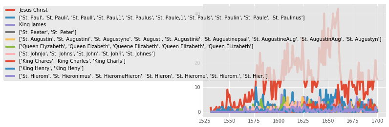

```python
# Create an initial, messy plot of those names and their degree over time
tf = df.T
tf.plot()
```

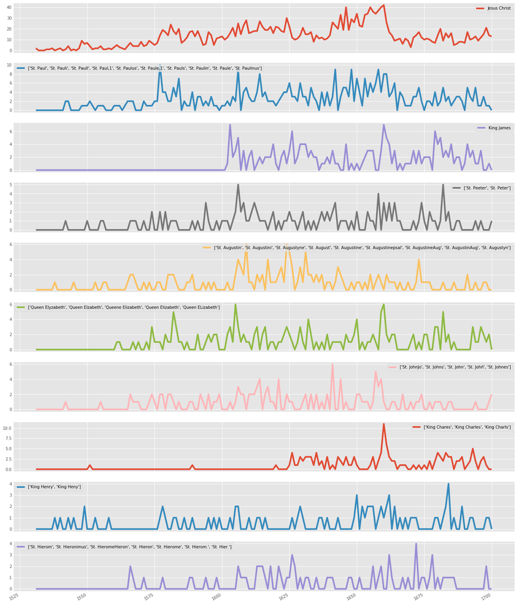

```python
# Separate that plot to make it more readable
ax = tf.plot(subplots=True, figsize=(20,30))
```

```python
# To get the graph for the "projected degree" over time, I needed to
# project every subgraph and record the degree
degree_projected = {}

for year,G in graphs_by_year.items():
    sub_people_nodes = {n for n, d in G.nodes(data=True) if d['bipartite']==1}
    projected_G = bipartite.projected_graph(G, sub_people_nodes)
    degree_projected[year] = dict(projected_G.degree())
```

```
array([<matplotlib.axes._subplots.AxesSubplot object at 0x7ff017f55f28>,
      dtype=object)
```

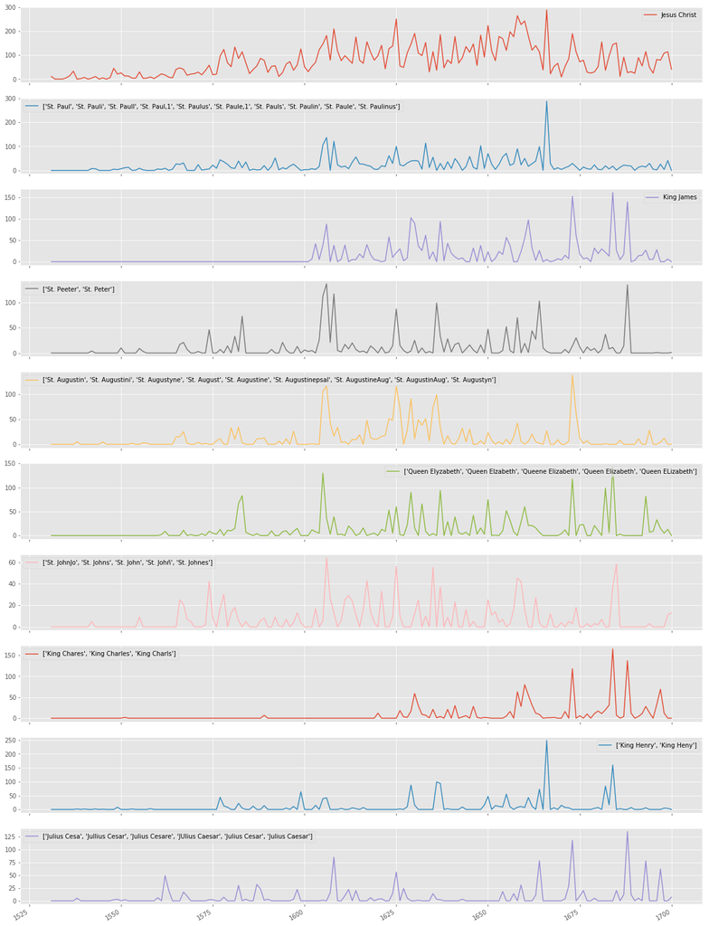

```python
# Using the same function as before, create a datafram of this and plot it
dcdf = create_dataframe(degree_projected,top_people)
tdcdf = dcdf.T
tdcdf.plot(subplots=True, figsize=(20,30))
```

```python
# Get the betweenness centrality for every node in the full network
# This takes a very long time to run
all_betweenness = bipartite.betweenness_centrality(B, people_nodes)
```

```python
# Because betweenness takes such a long time, save this in a "pickle"
# file for easy recall.
import pickle as pkl
with open('all_betweenness.pkl', 'wb') as f:
    pkl.dump(all_betweenness, f)
```

```python
# Need the itemgetter module for easier sorting
from operator import itemgetter

# Import all the betweenness measures from the file I just created
with open('all_betweenness.pkl', 'rb') as newf:
    all_betweenness = pkl.load(newf)

# Get betweenness for just the people nodes and sort them
all_betweenness_people = {k:v for k,v in all_betweenness.items() if k in people_nodes}
all_betweenness_sorted = sorted(all_betweenness_people.items(), key=itemgetter(1), reverse=True)
print(all_betweenness_sorted[:10])

# Keep track of the ids and get the top ten nodes by betweenness
abs_ids = [a[0] for a in all_betweenness_sorted[:10]]
top_ten_betweenness = []
for a in abs_ids:
    for n in B.nodes(data=True):
        if n[0] == a:
            top_ten_betweenness.append(n)

print(top_ten_betweenness)
```

```
[('1014540', 0.5855815007981192), ('1025452', 0.06100621600152451), ('1003023', 0.03582414258025156), ('1021103', 0.024379315181849836), ('1022189', 0.02335770872789311), ('1030589', 0.01941719475895441), ('1005539', 0.017173384947129475), ('1028742', 0.016981900364764463), ('1015145', 0.01197183692…
[('1014540', {'author': None, 'bipartite': 1, 'date': None, 'deg_rank': 1, 'degree': 8198, 'name_variants': 'Jesus Christ', 'title': None}), ('1025452', {'author': None, 'bipartite': 1, 'date': None, 'deg_rank': 2, 'degree': 834, 'name_variants': "['St. Paul', 'St. Pauli', 'St. Paull', 'St. Paul,1',…
```

```python
# To track betweenness over time, find betweenness centralities in every subgraph
# This is the same as with degree, above.
betweenness = {}

for year,G in graphs_by_year.items():
    sub_people_nodes = {n for n, d in G.nodes(data=True) if d['bipartite']==1}
    sub_text_nodes = set(G) - sub_people_nodes
    if len(sub_people_nodes) > 1 and len(sub_text_nodes) > 1:
        betweenness[year] = bipartite.betweenness_centrality(G, sub_people_nodes)
```

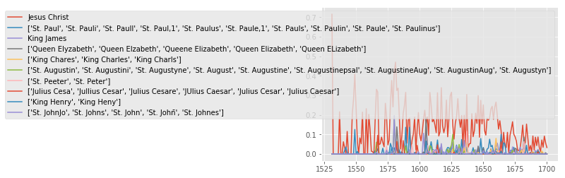

```python
# Create a dataframe and plot messily, as before
bdf = create_dataframe(betweenness,top_ten_betweenness)
tbdf = bdf.T
tbdf.plot()
```

```
array([<matplotlib.axes._subplots.AxesSubplot object at 0x7ff01ab2cb00>,
      dtype=object)
```

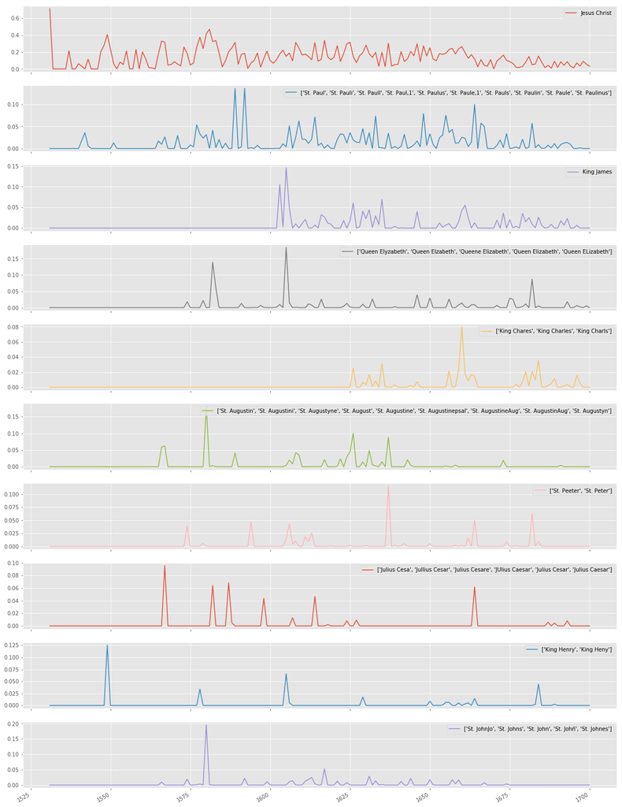

```python
# Plot cleanly
tbdf.plot(subplots=True, figsize=(20,30))
```

```python
# Create a dataframe of betweenness centrality for all people in the graph
all_people = [(n,d) for n,d in B.nodes(data=True) if d['bipartite'] == 1]
all_bdf = create_dataframe(betweenness, all_people)
# As an example, print out the 10 people with the highest betweenness in 1603.
all_bdf.nlargest(10,columns=1603)
```

|  | 1531 | 1532 | 1536 | 1537 | 1538 | 1539 | 1540 | 1542 | 1543 | 1544 | ... | 1691 | 1692 | 1693 | 1694 | 1695 | 1696 | 1697 | 1698 | 1699 | 1700 |
| --- | --- | --- | --- | --- | --- | --- | --- | --- | --- | --- | --- | --- | --- | --- | --- | --- | --- | --- | --- | --- | --- |
| Jesus Christ | 0.714286 | 0.0 | 0.0 | 0.215686 | 0.0 | 0.0 | 0.062284 | 0.0 | 0.115152 | 0.0 | ... | 0.085689 | 0.042491 | 0.086885 | 0.033993 | 0.01251 | 0.071366 | 0.033938 | 0.091062 | 0.056952 | 0.032639 |
| King James | 0.000000 | 0.0 | 0.0 | 0.000000 | 0.0 | 0.0 | 0.000000 | 0.0 | 0.000000 | 0.0 | ... | 0.017865 | 0.007145 | 0.023081 | 0.000000 | 0.00000 | 0.006658 | 0.000000 | 0.000000 | 0.000000 | 0.000000 |
| Robert Lee | 0.000000 | 0.0 | 0.0 | 0.000000 | 0.0 | 0.0 | 0.000000 | 0.0 | 0.000000 | 0.0 | ... | 0.000000 | 0.000000 | 0.000000 | 0.000000 | 0.00000 | 0.000000 | 0.000000 | 0.000000 | 0.000000 | 0.000000 |
| ['Andr. Willet', 'Andrew Willet'] | 0.000000 | 0.0 | 0.0 | 0.000000 | 0.0 | 0.0 | 0.000000 | 0.0 | 0.000000 | 0.0 | ... | 0.000000 | 0.000000 | 0.000000 | 0.000000 | 0.00000 | 0.000000 | 0.000000 | 0.000000 | 0.000000 | 0.000000 |
| ['Queen Elyzabeth', 'Queen Elzabeth', 'Queene Elizabeth', 'Queen Elizabeth', 'Queen ELizabeth'] | 0.000000 | 0.0 | 0.0 | 0.000000 | 0.0 | 0.0 | 0.000000 | 0.0 | 0.000000 | 0.0 | ... | 0.000000 | 0.000000 | 0.018138 | 0.000000 | 0.00000 | 0.006409 | 0.002144 | 0.000000 | 0.005610 | 0.000000 |
| ['King Henrie', 'King Henrye', 'King Henry'] | 0.000000 | 0.0 | 0.0 | 0.000000 | 0.0 | 0.0 | 0.000000 | 0.0 | 0.000000 | 0.0 | ... | 0.000000 | 0.000000 | 0.000000 | 0.000000 | 0.00000 | 0.000000 | 0.000000 | 0.000000 | 0.000000 | 0.000000 |
| Thomas Bell | 0.000000 | 0.0 | 0.0 | 0.000000 | 0.0 | 0.0 | 0.000000 | 0.0 | 0.000000 | 0.0 | ... | 0.000000 | 0.000000 | 0.000000 | 0.000000 | 0.00000 | 0.000000 | 0.000000 | 0.000000 | 0.000000 | 0.000000 |
| ['John Swinerton', 'John Swinnerton', 'John Swinnarton'] | 0.000000 | 0.0 | 0.0 | 0.000000 | 0.0 | 0.0 | 0.000000 | 0.0 | 0.000000 | 0.0 | ... | 0.000000 | 0.000000 | 0.000000 | 0.000000 | 0.00000 | 0.000000 | 0.000000 | 0.000000 | 0.000000 | 0.000000 |
| ['Richard Jobson', 'Richard Jhonson', 'Richard Johnson'] | 0.000000 | 0.0 | 0.0 | 0.000000 | 0.0 | 0.0 | 0.000000 | 0.0 | 0.000000 | 0.0 | ... | 0.000000 | 0.000000 | 0.000000 | 0.000000 | 0.00000 | 0.000000 | 0.000000 | 0.000000 | 0.000000 | 0.000000 |
| ['Thomas Playfere', 'Thomas Playfore'] | 0.000000 | 0.0 | 0.0 | 0.000000 | 0.0 | 0.0 | 0.000000 | 0.0 | 0.000000 | 0.0 | ... | 0.000000 | 0.000000 | 0.000000 | 0.000000 | 0.00000 | 0.000000 | 0.000000 | 0.000000 | 0.000000 | 0.000000 |

10 rows × 166 columns

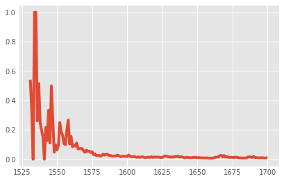

```python
# Get the densities of each subgraph
b_densities = []
for year,G in graphs_by_year.items():
    sub_people_nodes = {n for n, d in G.nodes(data=True) if d['bipartite']==1}
    b_densities.append(bipartite.density(G, sub_people_nodes))

# Create a simple line graph of these densities
densities = pd.Series(b_densities, index=range(1531,1701))#pd.period_range(start='1531',end='1700', freq='Y'))
densities.plot()
```

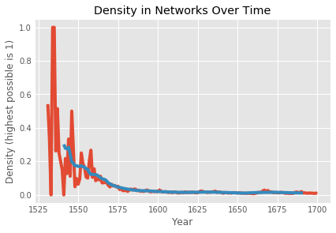

```python
# Plot the same graph with a rolling average trendline and better labels
densities.plot()
day_densities = densities.rolling(20, center=True).mean()
ax = day_densities.plot(title='Density in Networks Over Time')
ax.set_xlabel('Year')
ax.set_ylabel('Density (highest possible is 1)')
```

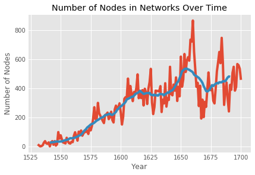

```python
# Plot a similar graph, but for nodecount over time instead of density
node_count = pd.Series([len(G.nodes()) for d,G in graphs_by_year.items()], index=range(1531,1701))#pd.period_range(start='1531',end='1700', freq='Y'))
ax = node_count.plot(title='Number of Nodes in Networks Over Time')
ax.set_xlabel('Year')
ax.set_ylabel('Number of Nodes')
node_count.rolling(20, center=True).mean().plot()
```

## Analyze Network by Decade

In addition to looking at changes year-by-year, I wanted the option of looking at changes from decade to decade. I devised a similar slicing method to the one above to create decade subgraphs.

```python
def filter_by_range(start_year,end_year):
    """
    Similar to the year filter (above), filter the
    full graph by a range of years and create a subgraph.
    """
    nodes = []
    for n in B.nodes(data=True):
        try:
            if n[1]['date'] in range(start_year, end_year):
                nodes.append(n[0])
                nodes.extend(B.neighbors(n[0]))
        except KeyError:
            pass
    SB = B.subgraph(nodes)
    return SB
```

```python
# Create a subgraph for decades around the Civil War/Interregnum period (and immediately before and after)
decade_graphs = {'1630s':filter_by_range(1630,1639),'1640s':filter_by_range(1639,1649), '1650s':filter_by_range(1650,1659), '1660s':filter_by_range(1660,1669)}
```

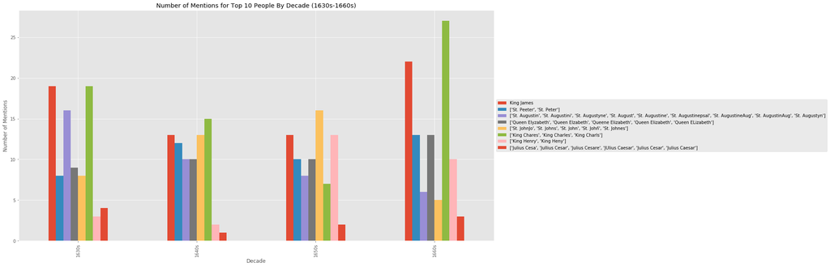

```python
# Find centralities by decade
decade_centralities = {year:dict(G.degree()) for year,G in decade_graphs.items()}

# Create a dataframe for the top ten people (but eliminate Christ and St. Paul for readability)
dbdf = create_dataframe(decade_centralities,top_people[2:])
tdbdf = dbdf.T
# Plot as a bar graph instead of a line graph
ax = tdbdf.plot(kind='bar', figsize=(20,10), title="Number of Mentions for Top 10 People By Decade (1630s-1660s)")
ax.set_xlabel('Decade')
ax.set_ylabel('Number of Mentions')
plt.legend(loc='center left', bbox_to_anchor=(1.0, 0.5))
```

```python
# Calculate betweenness by decade
# Again, this takes a while so I "pickled" the results
decade_betweenness = {}

for year,G in decade_graphs.items():
    sub_people_nodes = {n for n, d in G.nodes(data=True) if d['bipartite']==1}
    sub_text_nodes = set(G) - sub_people_nodes
    if len(sub_people_nodes) > 1 and len(sub_text_nodes) > 1:
        decade_betweenness[year] = bipartite.betweenness_centrality(G, sub_people_nodes)

with open('decade_betweenness.pkl', 'wb') as f:
    pkl.dump(decade_betweenness, f)
```

```python
# Find and print highest betweenness centralities for each decade
for decade,b in decade_betweenness.items():
    people_by_b = {k:v for k,v in b.items() if B.node[k]['bipartite'] == 1}
    people_by_b = sorted(people_by_b.items(), key= lambda m:m[1], reverse=True)
    print(decade)
    top_ten = people_by_b[:10]
    for t in top_ten:
        print(B.node[t[0]]['name_variants'], t[1])
    print()
```

```
1630s
Jesus Christ 0.3797640253259079
['St. Augustin', 'St. Augustini', 'St. Augustyne', 'St. August', 'St. Augustine', 'St. Augustinepsal', 'St. AugustineAug', 'St. AugustinAug', 'St. Augustyn'] 0.05575886984993333
King James 0.039340263179824926
['St. Paul', 'St. Pauli', 'St. Paull', 'St. Paul,1', 'St. Paulus', 'St. Paule,1', 'St. Pauls', 'St. Paulin', 'St. Paule', 'St. Paulinus'] 0.0317770605644912
['Queen Elyzabeth', 'Queen Elzabeth', 'Queene Elizabeth', 'Queen Elizabeth', 'Queen ELizabeth'] 0.02782462343370077
['King Chares', 'King Charles', 'King Charls'] 0.027641639300256555
['Thomas Lord Coven', 'Thomas Coven'] 0.017867717561302683
Thomas Goodwin 0.015930217450061696
['St. Peeter', 'St. Peter'] 0.01540793275338713
['Privi Council', 'Prive Council'] 0.014445054963216738

1640s
Jesus Christ 0.39708102667563094
['St. Paul', 'St. Pauli', 'St. Paull', 'St. Paul,1', 'St. Paulus', 'St. Paule,1', 'St. Pauls', 'St. Paulin', 'St. Paule', 'St. Paulinus'] 0.031999328503776535
['Thomas Fairfax', 'Thomas Lord Fairfax', 'Thomas Fairefax', 'Thomas Farfax'] 0.022298928526554067
King James 0.020612727706671715
['Tertul. Apol', 'Tertul Apol.', 'Tertul. Apo.', 'Tertul. Apol.'] 0.01916515346485618
['William Prynne', 'William Pryn', 'William Prynn'] 0.01763603289033634
['Clem. Alex. Stro.', 'Clm. Alex. Stro.', 'Clem. Alex. Strom.', 'Clem Alex. Strom.'] 0.014076926570403485
Abraham Reynardson 0.012007458166559163
['King Chares', 'King Charles', 'King Charls'] 0.011372045599456366
['John Ley', 'John Laey', 'John Ley.'] 0.010279250589475474

1650s
Jesus Christ 0.4317924400186835
['St. Paul', 'St. Pauli', 'St. Paull', 'St. Paul,1', 'St. Paulus', 'St. Paule,1', 'St. Pauls', 'St. Paulin', 'St. Paule', 'St. Paulinus'] 0.04639875396296573
['Almae Matri', 'Matri Almae'] 0.016833160736012726
['St. JohnJo', 'St. Johns', 'St. John', 'St. John̄', 'St. Johnes'] 0.01611526025787223
['Oliver Cromwel', 'Oliver Lord Cromwell', 'Oliver Cromwell', 'Oliver Crumwell', 'Oliver Crumwel'] 0.014898440901899648
King James 0.01429563286252777
['Queen Elyzabeth', 'Queen Elzabeth', 'Queene Elizabeth', 'Queen Elizabeth', 'Queen ELizabeth'] 0.013057350568486307
['William Lord Lenthal', 'William Lenthall', 'William Lenthal', 'Wiiam Lenthall'] 0.010820547463295858
['Patriarch Joseph', 'Joseph Patriarchae'] 0.009741299537534377
['Accademia Oxoniensi', 'Academiae Oxoniensis', 'Oxoniensis Academia', 'Academia Oxoniensi', 'Academiae Oxoniensi'] 0.008345047638173014

1660s
Jesus Christ 0.3537944423864458
['St. Paul', 'St. Pauli', 'St. Paull', 'St. Paul,1', 'St. Paulus', 'St. Paule,1', 'St. Pauls', 'St. Paulin', 'St. Paule', 'St. Paulinus'] 0.05971877615220196
['King Chares', 'King Charles', 'King Charls'] 0.03582674120562477
King James 0.03174523784433082
['Richard brown', 'Richard Browne', 'Richard Brown'] 0.018167472660697043
['King Henry', 'King Heny'] 0.015285028573642934
['Majesty Charls', 'Maiesty Charles', 'Majsty Charles', 'Majesty Charles'] 0.014536149406701077
['God Almighty', 'Almightye God', 'Almighty God', 'Allmighty God', 'Almighty God!'] 0.013683646712427196
['Accademia Oxoniensi', 'Academiae Oxoniensis', 'Oxoniensis Academia', 'Academia Oxoniensi', 'Academiae Oxoniensi'] 0.013400262519762814
['Doct. Sanderson', 'Doctor Sanderson'] 0.011957978160050571
```

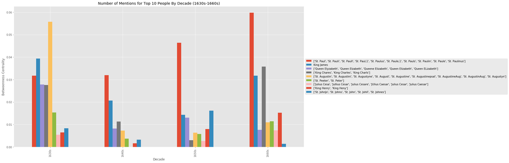

```python
# Create a datagrame and graph these results (eliminate Christ for readability)
ddf = create_dataframe(decade_betweenness,top_ten_betweenness[1:])
tddf = ddf.T
ax = tddf.plot(kind='bar', figsize=(20,10), title="Number of Mentions for Top 10 People By Decade (1630s-1660s)")
ax.set_xlabel('Decade')
ax.set_ylabel('Betweenness Centrality')
plt.legend(loc='center left', bbox_to_anchor=(1.0, 0.5))
```